# Project 1: SAT & ACT Analysis

## Problem Statement

> SAT participation rates are behind ACT participation rates in the USA on a state level. Our department has been given funds to increase the participation rate and we need to know where best to invest the fund to increase our participation rates.

## Executive Summary

In this project, we seek to use SAT and ACT data to determine where to best use funds to increase SAT participation rates.  
Through our research, we have found the following:

1. There is a strong negative correlation between participation rates and test scores. However, this is likely due to the student demographic taking the tests and we cannot use this correlation to improve our participation rates.
2. There is a strong negative correlation between SAT and ACT participation rates. However, as we are unable to control ACT participation rates, we are unable to utilize this correlation to improve our participation rates.
3. There is a slight correlation between participation rates and whether the candidates have taken the PSATs before. We will be able to utilize this correlation with further study to ensure the PSAT's efficacy.

We conclude from our data analysis that only promoting the PSAT seems to be a viable use of funds based on the data. Aside from promoting the PSATs, the College Board should continue with its current efforts in pushing for statewide assessment contracts, promoting its 'SAT School Day' initiative, and provide value-added services to potential candidates.

```python
final[((final['s17_Participation']==100) & (final['s18_Participation']!=100))|\
        ((final['s17_Participation']!=100) & (final['s18_Participation']==100))]\
        [['s17_Participation','s18_Participation']]
```

| State | s17_Participation | s18_Participation |
| --- | --- | --- |
| Colorado | 11 | 100 |
| District of Columbia | 100 | 92 |
| Idaho | 93 | 100 |

Colorado is of note as its SAT participation rate jumped from 11 to 100% from 2017 to 2018.  
The District of Columbia is of note as its SAT participation rate dropped from 100 to 92% from 2017 to 2018.  
Idaho is of note as its SAT participation rate increased from 93 to 100% from 2017 to 2018.

```python
final[((final['a17_Participation']==100) & (final['a18_Participation']!=100))|\
        ((final['a17_Participation']!=100) & (final['a18_Participation']==100))]\
        [['a17_Participation','a18_Participation']]
```

| State | a17_Participation | a18_Participation |
| --- | --- | --- |
| Colorado | 100 | 30 |
| Minnesota | 100 | 99 |
| Nebraska | 84 | 100 |
| Ohio | 75 | 100 |

Colorado is of note as its ACT participation rate dropped from 100 to 30% from 2017 to 2018.  
Minnesota is **not** of note as its ACT participation rate *only* dropped from 100 to 99% from 2017 to 2018.  
Nebraska is of note as its ACT participation rate increased from 84 to 100% from 2017 to 2018.  
Ohio is of note as its ACT participation rate increased from 75 to 100% from 2017 to 2018.

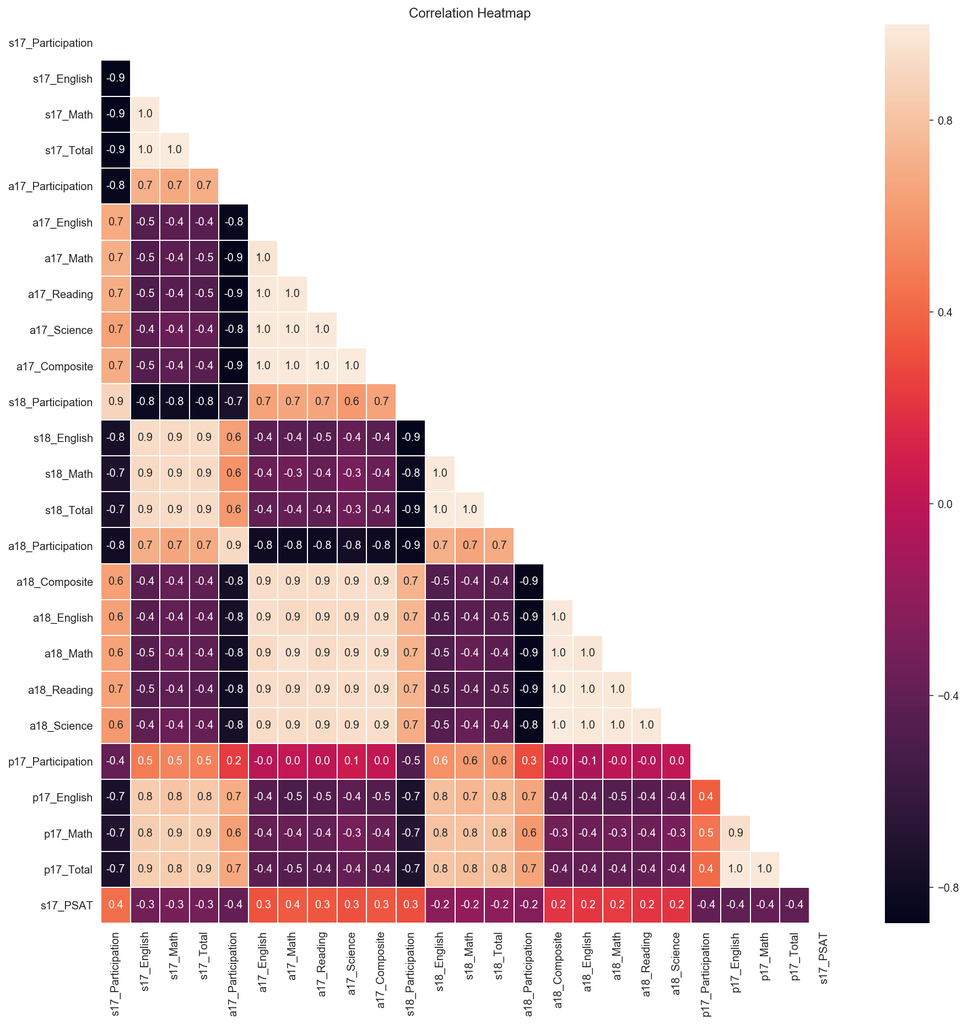

```python
#Create correlation heatmap of all features in 'final'
fig, ax = plt.subplots(figsize=(15,15))
corr = np.corrcoef(final.corr())
mask = np.zeros_like(corr)
mask[np.triu_indices_from(mask)] = True #Create upper triangular mask
sns.heatmap(final.corr(),linewidths=.5,ax=ax,mask=mask,annot=True,fmt='.1f') #Enable correlation values to 1 d.p.
ax.set_title('Correlation Heatmap')
plt.show()
```

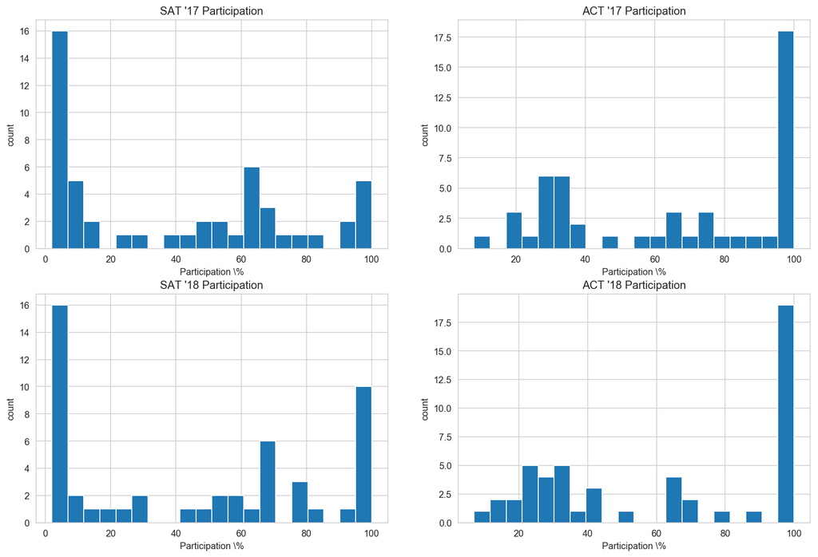

```python
# Participation rates for SAT & ACT
columns=['s17_Participation','a17_Participation','s18_Participation','a18_Participation']
titles=['SAT \'17 Participation','ACT \'17 Participation','SAT \'18 Participation','ACT \'18 Participation']
subplot_histograms(final,columns,list_of_titles=titles,figsize=(15,10),commonxlabel='Participation \%',commonylabel='count')
```

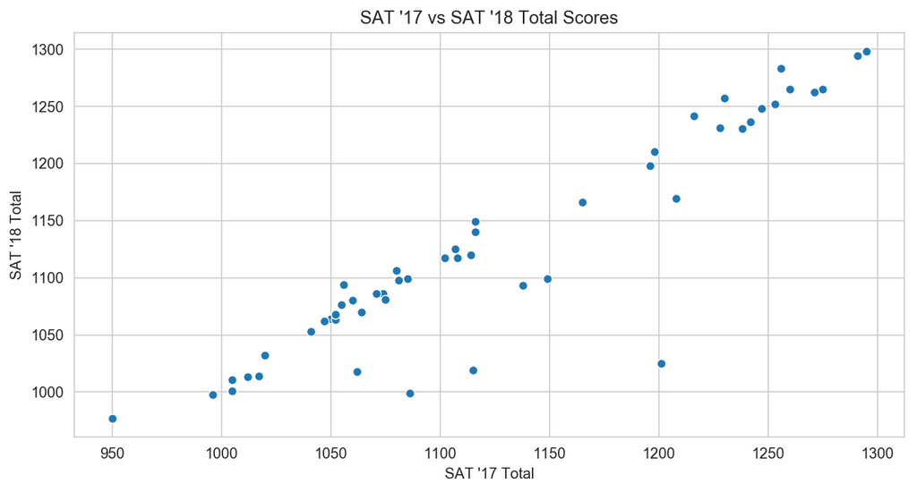

```python
# Total scores for SAT 2017 vs. 2018
scatplt(final,'s17_Total','s18_Total',figsize=(10,5),title='SAT \'17 vs SAT \'18 Total Scores',xlabel='SAT \'17 Total',ylabel='SAT \'18 Total')
```

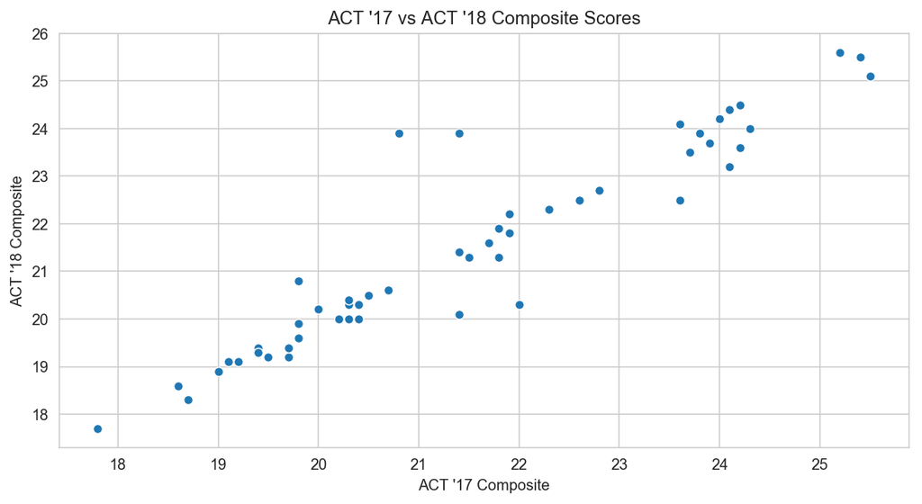

```python
# Composite scores for ACT 2017 vs. 2018
scatplt(final,'a17_Composite','a18_Composite',figsize=(10,5),title='ACT \'17 vs ACT \'18 Composite Scores',xlabel='ACT \'17 Composite',ylabel='ACT \'18 Composite')
```

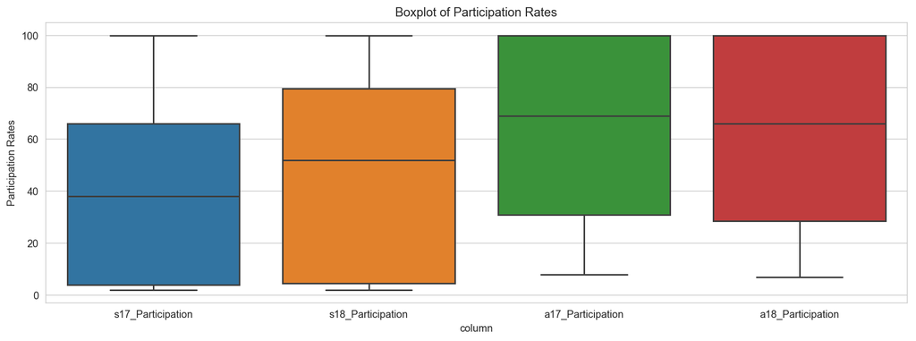

```python
#boxplot of Participation Rates
boxplt(final,['s17_Participation','s18_Participation','a17_Participation','a18_Participation'],figsize=(15,5),title='Boxplot of Participation Rates',xlabel='column',ylabel='Participation Rates')
```

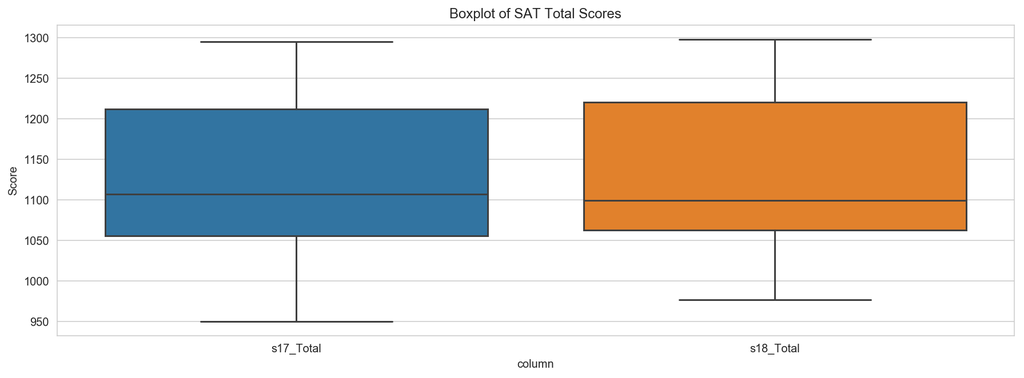

```python
#boxplot of SAT total scores
list=['s17_Total','s18_Total']
boxplt(final,list,figsize=(15,5),title='Boxplot of SAT Total Scores',xlabel='column',ylabel='Score')
```

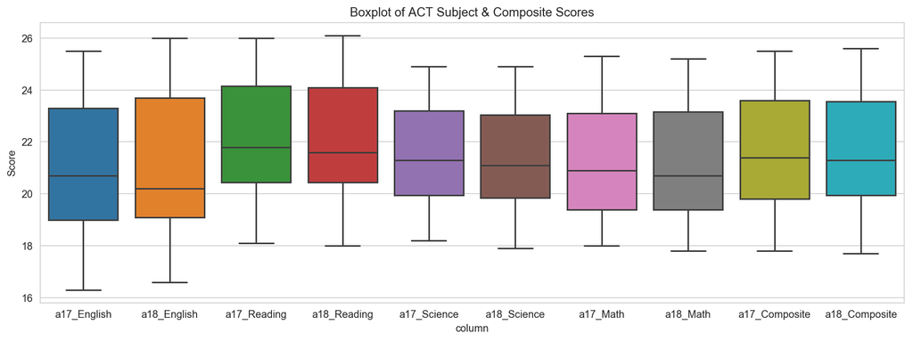

```python
#boxplot of ACT subject and composite scores
list=['a17_English','a18_English','a17_Reading','a18_Reading','a17_Science','a18_Science','a17_Math','a18_Math','a17_Composite','a18_Composite']
boxplt(final,list,figsize=(15,5),title='Boxplot of ACT Subject & Composite Scores',xlabel='column',ylabel='Score')
```

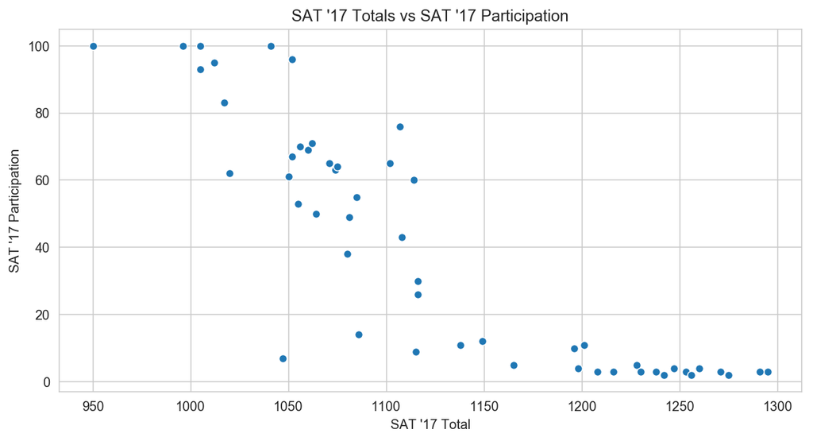

```python
scatplt(final,'s17_Total','s17_Participation',figsize=(10,5),title='SAT \'17 Totals vs SAT \'17 Participation',xlabel='SAT \'17 Total',ylabel='SAT \'17 Participation')
```

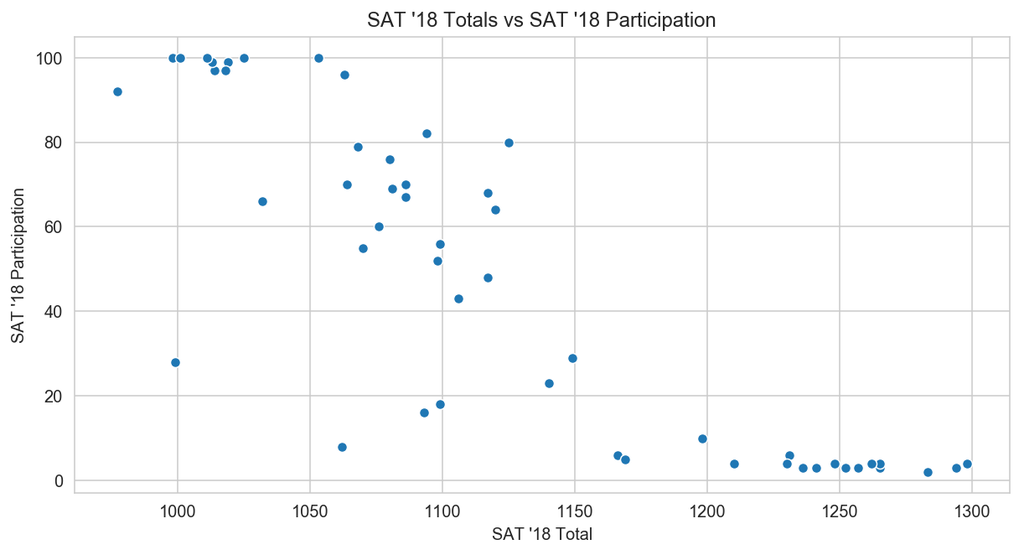

```python
scatplt(final,'s18_Total','s18_Participation',figsize=(10,5),title='SAT \'18 Totals vs SAT \'18 Participation',xlabel='SAT \'18 Total',ylabel='SAT \'18 Participation')
```

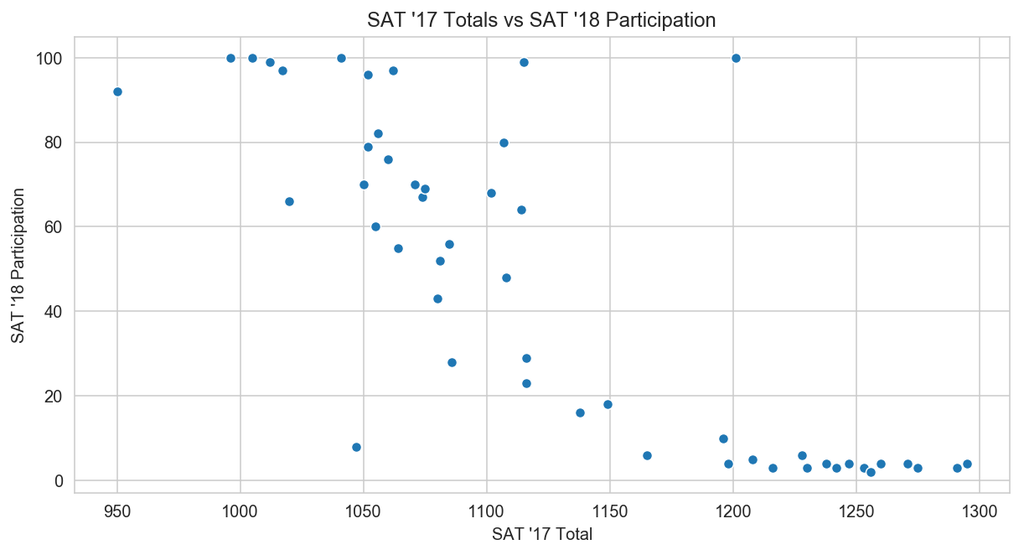

```python
scatplt(final,'s17_Total','s18_Participation',figsize=(10,5),title='SAT \'17 Totals vs SAT \'18 Participation',xlabel='SAT \'17 Total',ylabel='SAT \'18 Participation')
```

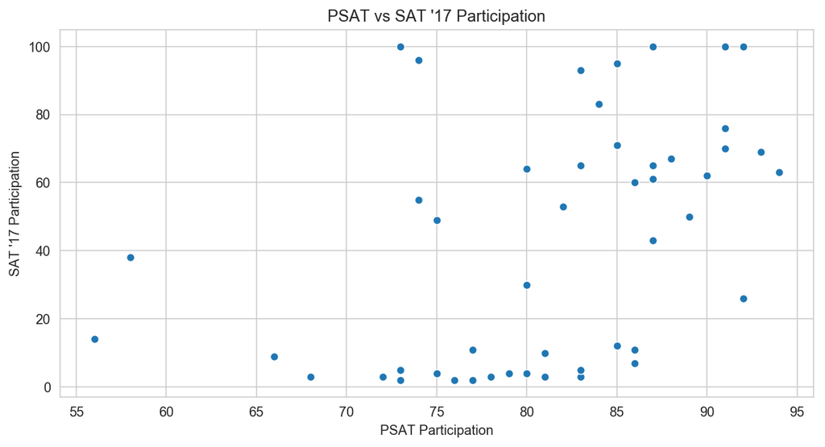

```python
scatplt(final,'s17_PSAT','s17_Participation',figsize=(10,5),title='PSAT vs SAT \'17 Participation',xlabel='PSAT Participation',ylabel='SAT \'17 Participation')
```

A positive correlation seems to be observed. However, the correlation coefficient is low at only 0.4 as observed from the heatmap plotted above. As such the PSATs cannot be said to be a strong predictor of SAT participation for prospective candidates.

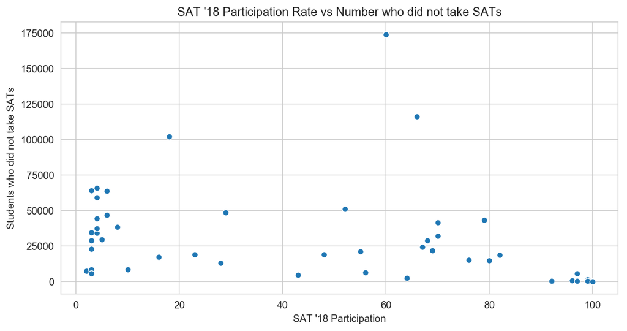

```python
scatplt(final,'s18_Participation','s18_nosatnum',figsize=(10,5),title='SAT \'18 Participation Rate vs Number who did not take SATs',xlabel='SAT \'18 Participation',ylabel='Students who did not take SATs')
```

```python
final[['s18_Participation','s18_nosatnum']].T
```

| State | Alabama | Alaska | Arizona | Arkansas | California | Colorado | Connecticut | Delaware | District of Columbia | Florida | ... | South Dakota | Tennessee | Texas | Utah | Vermont | Virginia | Washington | West Virginia | Wisconsin | Wyoming |
| --- | --- | --- | --- | --- | --- | --- | --- | --- | --- | --- | --- | --- | --- | --- | --- | --- | --- | --- | --- | --- | --- |
| s18_Participation | 6.0 | 43.0 | 29.0 | 5.0 | 60.0 | 100.0 | 100.0 | 100.0 | 92.0 | 97.0 | ... | 3.0 | 6.0 | 66.0 | 4.0 | 64.0 | 68.0 | 69.0 | 28.0 | 3.0 | 3.0 |
| s18_nosatnum | 46853.0 | 4444.0 | 48725.0 | 29570.0 | 174146.0 | 0.0 | 0.0 | 0.0 | 432.0 | 5439.0 | ... | 8442.0 | 63791.0 | 116148.0 | 37158.0 | 2440.0 | 28946.0 | 21795.0 | 12827.0 | 64259.0 | 5645.0 |

2 rows × 51 columns

If every state had the same population, we would expect a negative correlation to this graph. However, we notice that no such relation exists, which indicates that financially speaking, the best course of action is not to improve participation rates in the lowest participating states, but rather to focus on states with the highest untapped number of students.  
California is the biggest outlier here, where even though it already has 60% participation in the 2018 SATs, there are still 170 000 students who do not take the test, a multiple of the number from other states.

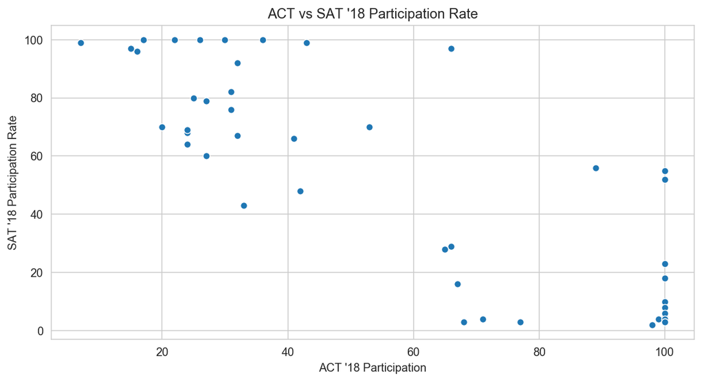

```python
scatplt(final,'a18_Participation','s18_Participation',figsize=(10,5),title='ACT vs SAT \'18 Participation Rate',xlabel='ACT \'18 Participation',ylabel='SAT \'18 Participation Rate')
```

```python
#Finding sum of 2018 SAT and ACT participation rates
l=[final['s18_Participation'][i]+final['a18_Participation'][i] for i in range(0,51)]
final['18_Participation']=l
final[['18_Participation']].T
```

| State | Alabama | Alaska | Arizona | Arkansas | California | Colorado | Connecticut | Delaware | District of Columbia | Florida | ... | South Dakota | Tennessee | Texas | Utah | Vermont | Virginia | Washington | West Virginia | Wisconsin | Wyoming |
| --- | --- | --- | --- | --- | --- | --- | --- | --- | --- | --- | --- | --- | --- | --- | --- | --- | --- | --- | --- | --- | --- |
| 18_Participation | 106 | 76 | 95 | 105 | 87 | 130 | 126 | 117 | 124 | 163 | ... | 80 | 106 | 107 | 104 | 88 | 92 | 93 | 93 | 103 | 103 |

1 rows × 51 columns

[figure not shown]

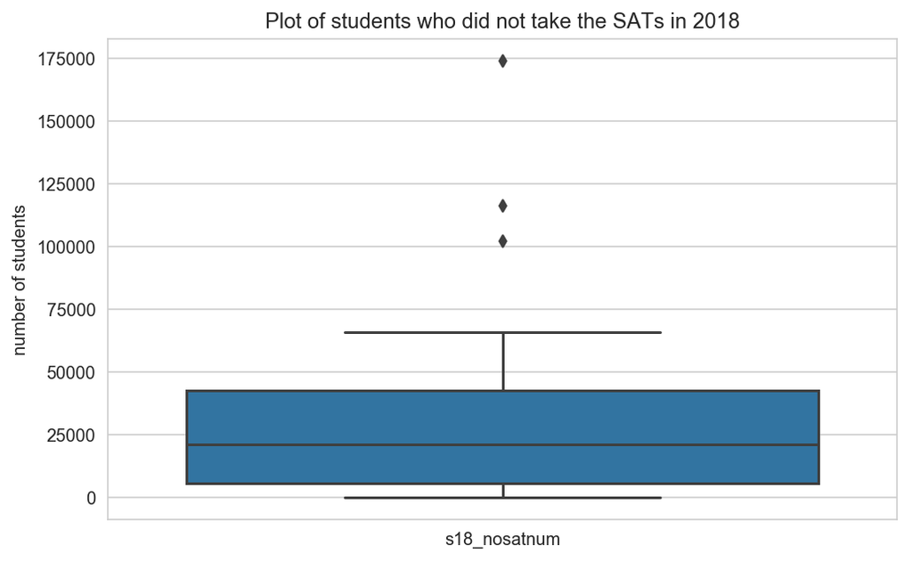

```python
subplot_histograms(final,list_of_columns=['s18_nosatnum'],figsize=(15,5)\
                   ,list_of_titles=['Histogram of students who did not take the SATs in 2018']\
                   ,commonxlabel='number of students',commonylabel='count of states')

boxplt(final,list_of_columns=['s18_nosatnum'],figsize=(8,5),\
        title='Plot of students who did not take the SATs in 2018',\
       xlabel=None,ylabel='number of students')
```

As mentioned previously, the number of states with a low number of students who did not take the SATs in 2018 is much more than the states with greater numbers. As such it is important to target efforts onto states with more students rather than based on participation rates.

```python
desc=desc.merge(test,left_index=True,right_index=True)
desc
```

|  | count | mean | std | min | 25% | 50% | 75% | max | IQR | CoeffVar | Skew |
| --- | --- | --- | --- | --- | --- | --- | --- | --- | --- | --- | --- |
| s17_Participation | 51.0 | 39.803922 | 35.276632 | 2.0 | 4.00 | 38.0 | 66.00 | 100.0 | 62.00 | 0.877528 | 0.336175 |
| s17_English | 51.0 | 569.117647 | 45.666901 | 482.0 | 533.50 | 559.0 | 613.00 | 644.0 | 79.50 | 0.079451 | 0.264607 |
| s17_Math | 51.0 | 556.882353 | 47.121395 | 468.0 | 523.50 | 548.0 | 599.00 | 651.0 | 75.50 | 0.083783 | 0.354215 |
| s17_Total | 51.0 | 1126.098039 | 92.494812 | 950.0 | 1055.50 | 1107.0 | 1212.00 | 1295.0 | 156.50 | 0.081328 | 0.301683 |
| a17_Participation | 51.0 | 65.254902 | 32.140842 | 8.0 | 31.00 | 69.0 | 100.00 | 100.0 | 69.00 | 0.487690 | -0.192118 |
| a17_English | 51.0 | 20.931373 | 2.353677 | 16.3 | 19.00 | 20.7 | 23.30 | 25.5 | 4.30 | 0.111339 | 0.342202 |
| a17_Math | 51.0 | 21.182353 | 1.981989 | 18.0 | 19.40 | 20.9 | 23.10 | 25.3 | 3.70 | 0.092646 | 0.322817 |
| a17_Reading | 51.0 | 22.013725 | 2.067271 | 18.1 | 20.45 | 21.8 | 24.15 | 26.0 | 3.70 | 0.092983 | 0.261378 |
| a17_Science | 51.0 | 21.450980 | 1.739353 | 18.2 | 19.95 | 21.3 | 23.20 | 24.9 | 3.25 | 0.080286 | 0.212334 |
| a17_Composite | 51.0 | 21.519608 | 2.020695 | 17.8 | 19.80 | 21.4 | 23.60 | 25.5 | 3.80 | 0.092975 | 0.310326 |
| s18_Participation | 51.0 | 46.627451 | 38.014187 | 2.0 | 4.50 | 52.0 | 79.50 | 100.0 | 75.00 | 0.807242 | 0.105437 |
| s18_English | 51.0 | 567.294118 | 45.317676 | 497.0 | 535.00 | 552.0 | 616.50 | 643.0 | 81.50 | 0.079097 | 0.348224 |
| s18_Math | 51.0 | 557.254902 | 48.887562 | 480.0 | 521.50 | 547.0 | 600.50 | 655.0 | 79.00 | 0.086865 | 0.411145 |
| s18_Total | 51.0 | 1124.666667 | 93.868561 | 977.0 | 1062.50 | 1099.0 | 1220.00 | 1298.0 | 157.50 | 0.082641 | 0.377547 |
| a18_Participation | 51.0 | 61.647059 | 34.080976 | 7.0 | 28.50 | 66.0 | 100.00 | 100.0 | 71.50 | 0.547393 | -0.021266 |
| a18_Composite | 51.0 | 21.486275 | 2.106278 | 17.7 | 19.95 | 21.3 | 23.55 | 25.6 | 3.60 | 0.097063 | 0.273600 |
| a18_English | 51.0 | 20.988235 | 2.446356 | 16.6 | 19.10 | 20.2 | 23.70 | 26.0 | 4.60 | 0.115410 | 0.360489 |
| a18_Math | 51.0 | 21.125490 | 2.035765 | 17.8 | 19.40 | 20.7 | 23.15 | 25.2 | 3.75 | 0.095416 | 0.261554 |
| a18_Reading | 51.0 | 22.015686 | 2.167245 | 18.0 | 20.45 | 21.6 | 24.10 | 26.1 | 3.65 | 0.097471 | 0.195390 |
| a18_Science | 51.0 | 21.345098 | 1.870114 | 17.9 | 19.85 | 21.1 | 23.05 | 24.9 | 3.20 | 0.086750 | 0.167271 |
| p17_Participation | 51.0 | 47.607843 | 14.387604 | 20.0 | 39.50 | 47.0 | 55.50 | 77.0 | 16.00 | 0.299233 | -0.029233 |
| p17_English | 51.0 | 530.313725 | 23.782759 | 480.0 | 511.00 | 530.0 | 549.00 | 573.0 | 38.00 | 0.044405 | 0.039219 |
| p17_Math | 51.0 | 516.705882 | 20.237879 | 471.0 | 502.50 | 514.0 | 532.00 | 561.0 | 29.50 | 0.038781 | 0.196164 |
| p17_Total | 51.0 | 1047.117647 | 43.280317 | 951.0 | 1010.00 | 1042.0 | 1080.00 | 1124.0 | 70.00 | 0.040926 | 0.087421 |
| s17_PSAT | 51.0 | 81.039216 | 8.275170 | 56.0 | 76.50 | 82.0 | 87.00 | 94.0 | 10.50 | 0.101107 | -0.885167 |

Answers:

```python
#Using mask to find outliers in table one standard dev away from the mean of the feature
final.mask((final>final.mean()-final.std(ddof=0))&(final<final.mean()+final.std(ddof=0)))
```

| State | s17_Participation | s17_English | s17_Math | s17_Total | a17_Participation | a17_English | a17_Math | a17_Reading | a17_Science | a17_Composite | ... | a18_Math | a18_Reading | a18_Science | p17_Participation | p17_English | p17_Math | p17_Total | s17_PSAT | s18_nosatnum | 18_Participation |
| --- | --- | --- | --- | --- | --- | --- | --- | --- | --- | --- | --- | --- | --- | --- | --- | --- | --- | --- | --- | --- | --- |
| Alabama | NaN | NaN | NaN | NaN | 100.0 | NaN | 18.4 | 19.7 | 19.4 | 19.2 | ... | 18.3 | 19.6 | 19.0 | NaN | NaN | NaN | NaN | NaN | NaN | NaN |
| Alaska | NaN | NaN | NaN | NaN | NaN | NaN | NaN | NaN | NaN | NaN | ... | NaN | NaN | NaN | NaN | NaN | NaN | NaN | 58.0 | NaN | 76.0 |
| Arizona | NaN | NaN | NaN | NaN | NaN | 18.6 | NaN | NaN | NaN | NaN | ... | NaN | 19.5 | 19.2 | NaN | NaN | NaN | NaN | NaN | NaN | NaN |
| Arkansas | 3.0 | NaN | NaN | NaN | 100.0 | NaN | 19.0 | 19.7 | 19.5 | 19.4 | ... | 18.9 | 19.7 | 19.4 | 27.0 | 560.0 | NaN | 1091.0 | NaN | NaN | NaN |
| California | NaN | NaN | NaN | NaN | 31.0 | NaN | NaN | NaN | NaN | NaN | ... | NaN | NaN | NaN | NaN | 501.0 | 492.0 | 994.0 | NaN | 174146.0 | 87.0 |
| Colorado | NaN | NaN | NaN | NaN | 100.0 | NaN | NaN | NaN | NaN | NaN | ... | 23.2 | 24.4 | 23.5 | 23.0 | 557.0 | 542.0 | 1099.0 | NaN | NaN | 130.0 |
| Connecticut | 100.0 | NaN | NaN | NaN | 31.0 | 25.5 | 24.6 | 25.6 | 24.6 | 25.2 | ... | 24.8 | 26.1 | 24.9 | NaN | NaN | 494.0 | NaN | 92.0 | NaN | NaN |
| Delaware | 100.0 | 503.0 | 492.0 | 996.0 | 18.0 | 24.1 | 23.4 | 24.8 | 23.6 | 24.1 | ... | NaN | 24.5 | 23.4 | NaN | NaN | NaN | NaN | 91.0 | NaN | NaN |
| District of Columbia | 100.0 | 482.0 | 468.0 | 950.0 | 32.0 | 24.4 | 23.5 | 24.9 | 23.5 | 24.2 | ... | NaN | 24.4 | NaN | NaN | 480.0 | 471.0 | 951.0 | NaN | NaN | NaN |
| Florida | 83.0 | 520.0 | 497.0 | 1017.0 | NaN | NaN | NaN | NaN | 19.4 | NaN | ... | NaN | NaN | NaN | 30.0 | NaN | 494.0 | 1004.0 | NaN | NaN | 163.0 |
| Georgia | NaN | NaN | NaN | NaN | NaN | NaN | NaN | NaN | NaN | NaN | ... | NaN | NaN | NaN | 22.0 | NaN | NaN | NaN | NaN | NaN | NaN |
| Hawaii | NaN | NaN | NaN | NaN | NaN | 17.8 | 19.2 | 19.2 | 19.3 | 19.0 | ... | 19.0 | 19.1 | 19.0 | NaN | NaN | NaN | NaN | NaN | NaN | 145.0 |
| Idaho | 93.0 | 513.0 | 493.0 | 1005.0 | NaN | NaN | NaN | NaN | NaN | NaN | ... | NaN | NaN | NaN | 26.0 | NaN | NaN | NaN | NaN | NaN | 136.0 |
| Illinois | NaN | NaN | NaN | NaN | NaN | NaN | NaN | NaN | NaN | NaN | ... | 23.4 | 24.2 | 23.4 | NaN | 506.0 | NaN | NaN | 66.0 | NaN | 142.0 |
| Indiana | NaN | NaN | NaN | NaN | NaN | NaN | NaN | NaN | NaN | NaN | ... | NaN | NaN | NaN | NaN | 501.0 | NaN | 998.0 | 94.0 | NaN | NaN |
| Iowa | 2.0 | 641.0 | 635.0 | 1275.0 | NaN | NaN | NaN | NaN | NaN | NaN | ... | NaN | NaN | NaN | 64.0 | 560.0 | 543.0 | 1103.0 | NaN | NaN | 71.0 |
| Kansas | 4.0 | 632.0 | 628.0 | 1260.0 | NaN | NaN | NaN | NaN | NaN | NaN | ... | NaN | NaN | NaN | NaN | 558.0 | 546.0 | 1104.0 | NaN | NaN | 75.0 |
| Kentucky | 4.0 | 631.0 | 616.0 | 1247.0 | 100.0 | NaN | NaN | NaN | NaN | NaN | ... | NaN | NaN | NaN | NaN | 568.0 | 542.0 | 1110.0 | NaN | NaN | NaN |
| Louisiana | 4.0 | NaN | NaN | NaN | 100.0 | NaN | 18.8 | 19.8 | 19.6 | 19.5 | ... | 18.5 | 19.6 | 19.1 | NaN | 556.0 | NaN | NaN | NaN | NaN | NaN |
| Maine | 95.0 | 513.0 | 499.0 | 1012.0 | 8.0 | 24.2 | 24.0 | 24.8 | 23.7 | 24.3 | ... | 23.6 | 24.7 | 23.4 | NaN | 501.0 | 489.0 | 991.0 | NaN | NaN | NaN |
| Maryland | NaN | NaN | NaN | NaN | 28.0 | 23.3 | NaN | 24.2 | 23.2 | 23.6 | ... | NaN | NaN | NaN | NaN | NaN | NaN | NaN | 93.0 | NaN | NaN |
| Massachusetts | 76.0 | NaN | NaN | NaN | 29.0 | 25.4 | 25.3 | 25.9 | 24.7 | 25.4 | ... | 25.2 | 25.9 | 24.7 | NaN | NaN | NaN | NaN | 91.0 | NaN | NaN |
| Michigan | 100.0 | 509.0 | 495.0 | 1005.0 | 29.0 | 24.1 | 23.7 | 24.5 | 23.8 | 24.1 | ... | 23.9 | 24.7 | 23.9 | NaN | NaN | NaN | NaN | NaN | NaN | NaN |
| Minnesota | 3.0 | 644.0 | 651.0 | 1295.0 | 100.0 | NaN | NaN | NaN | NaN | NaN | ... | NaN | NaN | NaN | 70.0 | 563.0 | 561.0 | 1124.0 | NaN | NaN | NaN |
| Mississippi | 2.0 | 634.0 | 607.0 | 1242.0 | 100.0 | 18.2 | 18.1 | 18.8 | 18.8 | 18.6 | ... | 18.1 | 18.9 | 18.6 | NaN | NaN | NaN | NaN | NaN | NaN | NaN |
| Missouri | 3.0 | 640.0 | 631.0 | 1271.0 | 100.0 | NaN | NaN | NaN | NaN | NaN | ... | NaN | NaN | NaN | NaN | 573.0 | 551.0 | 1124.0 | NaN | 65934.0 | NaN |
| Montana | NaN | NaN | NaN | NaN | 100.0 | NaN | NaN | NaN | NaN | NaN | ... | NaN | NaN | NaN | 72.0 | NaN | NaN | NaN | NaN | NaN | NaN |
| Nebraska | 3.0 | 629.0 | 625.0 | 1253.0 | NaN | NaN | NaN | NaN | NaN | NaN | ... | NaN | NaN | NaN | NaN | NaN | NaN | NaN | NaN | NaN | NaN |
| Nevada | NaN | NaN | NaN | NaN | 100.0 | 16.3 | 18.0 | 18.1 | 18.2 | 17.8 | ... | 17.8 | 18.0 | 17.9 | 21.0 | NaN | NaN | NaN | 92.0 | NaN | NaN |
| New Hampshire | 96.0 | NaN | NaN | NaN | 18.0 | 25.4 | 25.1 | 26.0 | 24.9 | 25.5 | ... | 24.7 | 25.6 | 24.4 | NaN | NaN | NaN | NaN | NaN | NaN | NaN |
| New Jersey | NaN | NaN | NaN | NaN | NaN | 23.8 | 23.8 | 24.1 | 23.2 | 23.9 | ... | 23.6 | NaN | NaN | NaN | 504.0 | NaN | NaN | 91.0 | NaN | NaN |
| New Mexico | NaN | NaN | NaN | NaN | NaN | 18.6 | NaN | NaN | NaN | NaN | ... | 19.1 | NaN | NaN | 26.0 | 495.0 | 488.0 | 983.0 | NaN | NaN | 83.0 |
| New York | NaN | NaN | NaN | NaN | 31.0 | 23.8 | 24.0 | 24.6 | 23.9 | 24.2 | ... | 24.2 | 24.9 | 24.2 | NaN | NaN | NaN | NaN | NaN | NaN | NaN |
| North Carolina | NaN | NaN | NaN | NaN | 100.0 | 17.8 | NaN | 19.6 | 19.3 | 19.1 | ... | NaN | 19.5 | 19.2 | NaN | NaN | NaN | NaN | NaN | NaN | 152.0 |
| North Dakota | 2.0 | 635.0 | 621.0 | 1256.0 | 98.0 | NaN | NaN | NaN | NaN | NaN | ... | NaN | NaN | NaN | 77.0 | NaN | 537.0 | NaN | NaN | NaN | NaN |
| Ohio | NaN | NaN | NaN | NaN | NaN | NaN | NaN | NaN | NaN | NaN | ... | NaN | NaN | NaN | NaN | NaN | NaN | NaN | NaN | 102068.0 | NaN |
| Oklahoma | NaN | NaN | NaN | NaN | 100.0 | 18.5 | 18.8 | NaN | 19.6 | 19.4 | ... | 18.8 | NaN | 19.4 | NaN | NaN | NaN | NaN | NaN | NaN | NaN |
| Oregon | NaN | NaN | NaN | NaN | NaN | NaN | NaN | NaN | NaN | NaN | ... | NaN | NaN | NaN | NaN | NaN | NaN | NaN | NaN | NaN | NaN |
| Pennsylvania | NaN | NaN | NaN | NaN | 23.0 | 23.4 | 23.4 | 24.2 | 23.3 | 23.7 | ... | 23.2 | NaN | NaN | NaN | NaN | NaN | NaN | NaN | NaN | NaN |
| Rhode Island | NaN | NaN | NaN | NaN | 21.0 | 24.0 | 23.3 | 24.7 | 23.4 | 24.0 | ... | 23.6 | 25.0 | 23.5 | NaN | 496.0 | 488.0 | 985.0 | NaN | NaN | NaN |
| South Carolina | NaN | NaN | NaN | NaN | 100.0 | 17.5 | 18.6 | 19.1 | 18.9 | 18.7 | ... | 18.2 | 18.6 | 18.5 | 20.0 | NaN | NaN | NaN | NaN | NaN | 155.0 |
| South Dakota | 3.0 | NaN | NaN | NaN | NaN | NaN | NaN | NaN | NaN | NaN | ... | NaN | NaN | NaN | 71.0 | 555.0 | 547.0 | 1102.0 | 68.0 | NaN | 80.0 |
| Tennessee | NaN | 623.0 | 604.0 | 1228.0 | 100.0 | NaN | 19.2 | NaN | NaN | NaN | ... | 19.1 | NaN | NaN | NaN | 572.0 | 547.0 | 1119.0 | NaN | 63791.0 | NaN |
| Texas | NaN | 513.0 | 507.0 | 1020.0 | NaN | NaN | NaN | NaN | NaN | NaN | ... | NaN | NaN | NaN | NaN | 489.0 | 490.0 | 979.0 | 90.0 | 116148.0 | NaN |
| Utah | 3.0 | 624.0 | 614.0 | 1238.0 | 100.0 | NaN | NaN | NaN | NaN | NaN | ... | NaN | NaN | NaN | 68.0 | 567.0 | 552.0 | 1119.0 | 72.0 | NaN | NaN |
| Vermont | NaN | NaN | NaN | NaN | 29.0 | 23.3 | NaN | 24.4 | 23.2 | 23.6 | ... | 23.4 | 24.9 | 23.8 | 69.0 | NaN | NaN | NaN | NaN | NaN | 88.0 |
| Virginia | NaN | NaN | NaN | NaN | 29.0 | 23.5 | 23.3 | 24.6 | 23.5 | 23.8 | ... | 23.3 | 24.7 | 23.5 | NaN | NaN | NaN | NaN | NaN | NaN | NaN |
| Washington | NaN | NaN | NaN | NaN | 29.0 | NaN | NaN | NaN | NaN | NaN | ... | NaN | NaN | NaN | NaN | NaN | NaN | NaN | NaN | NaN | NaN |
| West Virginia | NaN | NaN | NaN | NaN | NaN | NaN | NaN | NaN | NaN | NaN | ... | NaN | NaN | NaN | NaN | NaN | NaN | NaN | 56.0 | NaN | NaN |
| Wisconsin | 3.0 | 642.0 | 649.0 | 1291.0 | 100.0 | NaN | NaN | NaN | NaN | NaN | ... | NaN | NaN | NaN | 69.0 | NaN | NaN | NaN | NaN | 64259.0 | NaN |
| Wyoming | 3.0 | 626.0 | 604.0 | 1230.0 | 100.0 | NaN | NaN | NaN | NaN | NaN | ... | NaN | NaN | NaN | 68.0 | 563.0 | 541.0 | 1104.0 | NaN | NaN | NaN |

51 rows × 27 columns

> Above is a table displaying only the outliers one standard deviation away from the mean in the table.  
> What is most readily noticeable is how states with the highest participation rates perform the worst in tests and states with the lowest rates perform the best.  
> Another interesting point to note, is that some of the states with the lowest SAT participation rates also have the smallest number of students who did not take the SATs (indicating a small population size in the state in the first place).  
> As such, we should focus our efforts on raising participation rates in states with large numbers of students who do not intend to take the SATs. These three states will be California, Ohio, and Texas.

```python
#Two-tailed test for difference in SAT '17 and '18 Participation Rates:
stats.ttest_ind(final['s17_Participation'],final['s18_Participation'])
```

```
Ttest_indResult(statistic=-0.9396299045734346, pvalue=0.3496715691509279)
```

Where the null hypothesis $H_0$ is 'the difference between SAT '17 and '18 Participation Rates is 0', we conducted a two-tailed t-test in the cell above.  
The result is that there is a 34.9% probability that participation rates differ equal to or more than the amount observed in our sample assuming that our null hypothesis is true.  
As such, we cannot reject the null hypothesis as our $p$-value has not even reached the significance level of 0.05  
(i.e. the difference in Participation Rates year-on-year is not really statistically significant).  
This method of analysis conceals the fact that [there was a 25% net increase in participation of individuals](https://reports.collegeboard.org/sat-suite-program-results/class-2018-results).

> The 3 states I will investigate are (1) Colorado, (2) Florida, and (3) Iowa.  
> Colorado had the greatest change in participation rates for both SAT and ACT from 2017 to 2018.  
> Florida has the greatest sum of participation rates in 2018 and Iowa has the least.  
> The reason Colorado had such a great change in participation rates was a change in statewide assessment policy [switching](https://www.testive.com/colorado-sat-change-2017/) from the [ACT to SAT in 2017](https://www.chalkbeat.org/posts/co/2015/12/23/goodbye-act-hello-sat-a-significant-change-for-colorado-high-schoolers/). In 2015, [a bill was passed](http://extras.denverpost.com/app/bill-tracker/bills/2015a/hb_15-1323/) that mandated statewide assessment which was first conducted as the ACT, then switched to the SAT. The SATs are also now [viewed more favourably](https://www.edweek.org/ew/articles/2018/10/31/sat-scores-rise-as-number-of-test-takers.html) due to a redesign of the curriculum and initiatives such as 'SAT School Day' which helped the SAT win over states like Colorado.  
> The high participation rate in Florida for both the SAT and ACTs is interesting considering certain factors. Firstly, Florida [ranks low](https://www.governing.com/gov-data/education-data/state-education-spending-per-pupil-data.html) on state-education funding indicating lesser influence on the part of the state. The people of Florida are also [not ranked highly](https://en.wikipedia.org/wiki/List_of_U.S._states_by_educational_attainment#cite_note-datasource-1) in terms of educational attainment and by inference, her people would not be the type to participate in optional tests. It seems that Florida's high participation rate is due to the fact that [*'Florida students seeking admission to any of Florida’s state universities need to submit either an ACT or SAT score'*](https://www.orlandosentinel.com/news/education/os-ne-act-sat-florida-scores-20181024-story.html).  
> Florida's increase in SAT participation is also due to the aforementioned ['SAT School Day' initiative](https://www.orlandosentinel.com/news/education/os-ne-act-sat-florida-scores-20181024-story.html), and also due to a [partnership with Khan academy](https://www.orlandosentinel.com/news/education/os-ne-act-sat-florida-scores-20181024-story.html).  
> Iowa is also interesting, as in spite of its low participation rate, the [proportion of college going seniors is close to the US national average](http://publications.iowa.gov/28716/1/Condition%20of%20Higher%20Education%20in%20Iowa%202018.pdf).Iowa's colleges [do require either the SAT or ACTs](https://www.prepscholar.com/sat/s/colleges/University-of-Iowa-admission-requirements), and this indicates that only college-bound seniors choose to take the tests with the other graduating students not even attempting application to the colleges. It seems that there is also a [precedent for Iowa's low participation rates since 2007](https://wcfcourier.com/news/breaking_news/iowa-s-sat-scores-rank-high-nationally-participation-low/article_f59bcf7f-df03-53a7-bb6e-55a0caac633f.html).

## Conclusions and Recommendations

Based on all the data exploration, I would state that there are very few predictors of participation.  
My recommendation would be for the College Board to continue with their successful efforts in the following avenues:

- Convincing states that the revamped SATs are best-aligned to the high school curriculum, to get statewide assessment contracts (ala Colorado)
- Implementing 'SAT School Days' in as many state districts as possible (ala Florida), and
- To provide more value-added services like pairing up with Khan Academy to provide free online review lessons.

From the data, the most useful recommendation to be given would be for the College Board to promote the PSAT, as the PSAT participation shows a 0.4 positive correlation with SAT participation when students reach grade 11 or 12.

I wish to have more data on

- Students who took both the SAT and ACTs,
- PSAT and SAT data **before** the 2016 change in assessment (to determine if PSAT is a good predictor of SAT participation)
- 'SAT School Day' data (number of schools involved in different states)